# Assignment 1

Katherine Li

# Bronze Tier

Each task is worth 2 points.

## Task 1

Use the attrition data from the rsample package.

```r
library(rsample)

data("attrition")
```

Engage in some data exploration by using `summary` functions.

In addition to the `summary` function, the `describe` functions from the psych and Hmisc packages are great (but for slightly different purposes). Use any function you wish.

*(1) Use the summary function. From the results, we could see all the variables included in the dataset listed out. For the numeric ones, we could see the minimums, 1st quartile values, medians, 3rd quartile values, maximums, and means. For the categorical variables, we could see the levels/classes included.*

```r
summary(attrition)
```

```
##       Age        Attrition            BusinessTravel   DailyRate
##  Min.   :18.00   No :1233   Non-Travel       : 150   Min.   : 102.0
##  1st Qu.:30.00   Yes: 237   Travel_Frequently: 277   1st Qu.: 465.0
##  Median :36.00              Travel_Rarely    :1043   Median : 802.0
##  Mean   :36.92                                       Mean   : 802.5
##  3rd Qu.:43.00                                       3rd Qu.:1157.0
##  Max.   :60.00                                       Max.   :1499.0
##
##                 Department  DistanceFromHome         Education
##  Human_Resources     : 63   Min.   : 1.000   Below_College:170
##  Research_Development:961   1st Qu.: 2.000   College      :282
##  Sales               :446   Median : 7.000   Bachelor     :572
##                             Mean   : 9.193   Master       :398
##                             3rd Qu.:14.000   Doctor       : 48
##                             Max.   :29.000
##
##           EducationField EnvironmentSatisfaction    Gender
##  Human_Resources : 27    Low      :284           Female:588
##  Life_Sciences   :606    Medium   :287           Male  :882
##  Marketing       :159    High     :453
##  Medical         :464    Very_High:446
##  Other           : 82
##  Technical_Degree:132
##
##    HourlyRate       JobInvolvement    JobLevel
##  Min.   : 30.00   Low      : 83    Min.   :1.000
##  1st Qu.: 48.00   Medium   :375    1st Qu.:1.000
##  Median : 66.00   High     :868    Median :2.000
##  Mean   : 65.89   Very_High:144    Mean   :2.064
##  3rd Qu.: 83.75                    3rd Qu.:3.000
##  Max.   :100.00                    Max.   :5.000
##
##                       JobRole     JobSatisfaction  MaritalStatus
##  Sales_Executive          :326   Low      :289    Divorced:327
##  Research_Scientist       :292   Medium   :280    Married :673
##  Laboratory_Technician    :259   High     :442    Single  :470
##  Manufacturing_Director   :145   Very_High:459
##  Healthcare_Representative:131
##  Manager                  :102
##  (Other)                  :215
```

[output cut: 25 more lines]

```
##  Min.   : 0.000   Min.   : 0.000     Min.   : 0.000
##  1st Qu.: 3.000   1st Qu.: 2.000     1st Qu.: 0.000
##  Median : 5.000   Median : 3.000     Median : 1.000
##  Mean   : 7.008   Mean   : 4.229     Mean   : 2.188
##  3rd Qu.: 9.000   3rd Qu.: 7.000     3rd Qu.: 3.000
##  Max.   :40.000   Max.   :18.000     Max.   :15.000
##
##  YearsWithCurrManager
##  Min.   : 0.000
##  1st Qu.: 2.000
##  Median : 3.000
##  Mean   : 4.123
##  3rd Qu.: 7.000
##  Max.   :17.000
##
```

*(2) Now use the describe function from the package “Hmisc”. From this result, for numeric variables, we could see information like the lowest and highest values, the mean, if there is any missing value, and etc. For variables of the data type factor, we could see information like the proportions and frequencies of the included levels/classes, if there is any missing value, and etc.*

```r
# Load the required library.
library(Hmisc)

# Explore the data.
describe(attrition)
```

```
## attrition
##
##  31  Variables      1470  Observations
## ---------------------------------------------------------------------------
## Age
##        n  missing distinct     Info     Mean      Gmd      .05      .10
##     1470        0       43    0.999    36.92    10.33       24       26
##      .25      .50      .75      .90      .95
##       30       36       43       50       54
##
## lowest : 18 19 20 21 22, highest: 56 57 58 59 60
## ---------------------------------------------------------------------------
## Attrition
##        n  missing distinct
##     1470        0        2
##
## Value         No   Yes
## Frequency   1233   237
## Proportion 0.839 0.161
## ---------------------------------------------------------------------------
## BusinessTravel
##        n  missing distinct
##     1470        0        3
##
## Value             Non-Travel Travel_Frequently     Travel_Rarely
## Frequency                150               277              1043
## Proportion             0.102             0.188             0.710
## ---------------------------------------------------------------------------
## DailyRate
##        n  missing distinct     Info     Mean      Gmd      .05      .10
##     1470        0      886        1    802.5      466    165.4    242.8
##      .25      .50      .75      .90      .95
##    465.0    802.0   1157.0   1356.0   1424.1
##
## lowest :  102  103  104  105  106, highest: 1492 1495 1496 1498 1499
## ---------------------------------------------------------------------------
## Department
##        n  missing distinct
##     1470        0        3
##
```

[output cut: 256 more lines]

```
##        n  missing distinct     Info     Mean      Gmd      .05      .10
##     1470        0       18    0.976    4.123    3.904        0        0
##      .25      .50      .75      .90      .95
##        2        3        7        9       10
##
## lowest :  0  1  2  3  4, highest: 13 14 15 16 17
##
## Value          0     1     2     3     4     5     6     7     8     9
## Frequency    263    76   344   142    98    31    29   216   107    64
## Proportion 0.179 0.052 0.234 0.097 0.067 0.021 0.020 0.147 0.073 0.044
##
## Value         10    11    12    13    14    15    16    17
## Frequency     27    22    18    14     5     5     2     7
## Proportion 0.018 0.015 0.012 0.010 0.003 0.003 0.001 0.005
## ---------------------------------------------------------------------------
```

*(3) Now use the describe function included in the package “psych”. From the result, we could see things like the means, standard deviations, and medians of the 31 variables respectively.*

```r
# Load revelant library.
library(psych)

# Explore the data using relevant function.
psych::describe(attrition)
```

```
##                           vars    n     mean      sd  median  trimmed
## Age                          1 1470    36.92    9.14    36.0    36.47
## Attrition*                   2 1470     1.16    0.37     1.0     1.08
## BusinessTravel*              3 1470     2.61    0.67     3.0     2.76
## DailyRate                    4 1470   802.49  403.51   802.0   803.83
## Department*                  5 1470     2.26    0.53     2.0     2.25
## DistanceFromHome             6 1470     9.19    8.11     7.0     8.08
## Education*                   7 1470     2.91    1.02     3.0     2.98
## EducationField*              8 1470     3.25    1.33     3.0     3.10
## EnvironmentSatisfaction*     9 1470     2.72    1.09     3.0     2.78
## Gender*                     10 1470     1.60    0.49     2.0     1.62
## HourlyRate                  11 1470    65.89   20.33    66.0    66.02
## JobInvolvement*             12 1470     2.73    0.71     3.0     2.74
## JobLevel                    13 1470     2.06    1.11     2.0     1.90
## JobRole*                    14 1470     5.46    2.46     6.0     5.61
## JobSatisfaction*            15 1470     2.73    1.10     3.0     2.79
## MaritalStatus*              16 1470     2.10    0.73     2.0     2.12
## MonthlyIncome               17 1470  6502.93 4707.96  4919.0  5667.24
## MonthlyRate                 18 1470 14313.10 7117.79 14235.5 14286.48
## NumCompaniesWorked          19 1470     2.69    2.50     2.0     2.36
## OverTime*                   20 1470     1.28    0.45     1.0     1.23
## PercentSalaryHike           21 1470    15.21    3.66    14.0    14.80
## PerformanceRating*          22 1470     3.15    0.36     3.0     3.07
## RelationshipSatisfaction*   23 1470     2.71    1.08     3.0     2.77
## StockOptionLevel            24 1470     0.79    0.85     1.0     0.67
## TotalWorkingYears           25 1470    11.28    7.78    10.0    10.37
## TrainingTimesLastYear       26 1470     2.80    1.29     3.0     2.72
## WorkLifeBalance*            27 1470     2.76    0.71     3.0     2.77
## YearsAtCompany              28 1470     7.01    6.13     5.0     5.99
## YearsInCurrentRole          29 1470     4.23    3.62     3.0     3.85
## YearsSinceLastPromotion     30 1470     2.19    3.22     1.0     1.48
## YearsWithCurrManager        31 1470     4.12    3.57     3.0     3.77
##                               mad  min   max range  skew kurtosis     se
## Age                          8.90   18    60    42  0.41    -0.41   0.24
## Attrition*                   0.00    1     2     1  1.84     1.39   0.01
## BusinessTravel*              0.00    1     3     2 -1.44     0.69   0.02
## DailyRate                  510.01  102  1499  1397  0.00    -1.21  10.52
## Department*                  0.00    1     3     2  0.17    -0.40   0.01
## DistanceFromHome             7.41    1    29    28  0.96    -0.23   0.21
## Education*                   1.48    1     5     4 -0.29    -0.56   0.03
```

[output cut: 9 more lines]

```
## MonthlyIncome             3260.24 1009 19999 18990  1.37     0.99 122.79
## MonthlyRate               9201.76 2094 26999 24905  0.02    -1.22 185.65
## NumCompaniesWorked           1.48    0     9     9  1.02     0.00   0.07
## OverTime*                    0.00    1     2     1  0.96    -1.07   0.01
## PercentSalaryHike            2.97   11    25    14  0.82    -0.31   0.10
## PerformanceRating*           0.00    3     4     1  1.92     1.68   0.01
## RelationshipSatisfaction*    1.48    1     4     3 -0.30    -1.19   0.03
## StockOptionLevel             1.48    0     3     3  0.97     0.35   0.02
## TotalWorkingYears            5.93    0    40    40  1.11     0.91   0.20
## TrainingTimesLastYear        1.48    0     6     6  0.55     0.48   0.03
## WorkLifeBalance*             0.00    1     4     3 -0.55     0.41   0.02
## YearsAtCompany               4.45    0    40    40  1.76     3.91   0.16
## YearsInCurrentRole           4.45    0    18    18  0.92     0.47   0.09
## YearsSinceLastPromotion      1.48    0    15    15  1.98     3.59   0.08
## YearsWithCurrManager         4.45    0    17    17  0.83     0.16   0.09
```

## Task 2

How do those variables look? Do they appear to all make sense? Are there any extreme values? Are any of them coded in such a way that don’t make sense? Discuss anything interesting that you found.

Be sure to use the `str` function or the `glimpse` function from dplyr to check the structure of the data.

*(1) By using the str function, we could see the information such as the data types of the variables - we have types that include factor, ordered factor, and integer. For those variables of type factor and ordered factor, we could see how many levels are included in each of them.*

```r
# Use the str function.
str(attrition)
```

```
## 'data.frame':    1470 obs. of  31 variables:
##  $ Age                     : int  41 49 37 33 27 32 59 30 38 36 ...
##  $ Attrition               : Factor w/ 2 levels "No","Yes": 2 1 2 1 1 1 1 1 1 1 ...
##  $ BusinessTravel          : Factor w/ 3 levels "Non-Travel","Travel_Frequently",..: 3 2 3 2 3 2 3 3 2 3 ...
##  $ DailyRate               : int  1102 279 1373 1392 591 1005 1324 1358 216 1299 ...
##  $ Department              : Factor w/ 3 levels "Human_Resources",..: 3 2 2 2 2 2 2 2 2 2 ...
##  $ DistanceFromHome        : int  1 8 2 3 2 2 3 24 23 27 ...
##  $ Education               : Ord.factor w/ 5 levels "Below_College"<..: 2 1 2 4 1 2 3 1 3 3 ...
##  $ EducationField          : Factor w/ 6 levels "Human_Resources",..: 2 2 5 2 4 2 4 2 2 4 ...
##  $ EnvironmentSatisfaction : Ord.factor w/ 4 levels "Low"<"Medium"<..: 2 3 4 4 1 4 3 4 4 3 ...
##  $ Gender                  : Factor w/ 2 levels "Female","Male": 1 2 2 1 2 2 1 2 2 2 ...
##  $ HourlyRate              : int  94 61 92 56 40 79 81 67 44 94 ...
##  $ JobInvolvement          : Ord.factor w/ 4 levels "Low"<"Medium"<..: 3 2 2 3 3 3 4 3 2 3 ...
##  $ JobLevel                : int  2 2 1 1 1 1 1 1 3 2 ...
##  $ JobRole                 : Factor w/ 9 levels "Healthcare_Representative",..: 8 7 3 7 3 3 3 3 5 1 ...
```

[output cut: 17 more lines]

*(2) Then, use the glimpse function. The results basically looks similiar to the ones generated from the str function, except for the data of type ordered factor and factor, the result down below does not show the numbers of levels.*

```r
# Load relevant library.
library(dplyr)

# Use the glimpse function.
glimpse(attrition)
```

```
## Observations: 1,470
## Variables: 31
## $ Age                      <int> 41, 49, 37, 33, 27, 32, 59, 30, 38, 3...
## $ Attrition                <fct> Yes, No, Yes, No, No, No, No, No, No,...
## $ BusinessTravel           <fct> Travel_Rarely, Travel_Frequently, Tra...
## $ DailyRate                <int> 1102, 279, 1373, 1392, 591, 1005, 132...
## $ Department               <fct> Sales, Research_Development, Research...
## $ DistanceFromHome         <int> 1, 8, 2, 3, 2, 2, 3, 24, 23, 27, 16, ...
## $ Education                <ord> College, Below_College, College, Mast...
## $ EducationField           <fct> Life_Sciences, Life_Sciences, Other, ...
## $ EnvironmentSatisfaction  <ord> Medium, High, Very_High, Very_High, L...
## $ Gender                   <fct> Female, Male, Male, Female, Male, Mal...
## $ HourlyRate               <int> 94, 61, 92, 56, 40, 79, 81, 67, 44, 9...
## $ JobInvolvement           <ord> High, Medium, Medium, High, High, Hig...
## $ JobLevel                 <int> 2, 2, 1, 1, 1, 1, 1, 1, 3, 2, 1, 2, 1...
```

[output cut: 18 more lines]

*To conclude the data exploration process, I think most of the dataset looks rational concerning with in-real-life intuitions. However, I spot some points that might need attention and further inspection: firstly, the data types for variables for job level and stock option level should be factors instead of integers. Secondly, the first two levels under the variable performance rating appear to be zeros, which might not make sense, but more information would be needed to determine if this data distribution is correctly recorded. Thirdly, for variable attrition, the ones labeled as “no” take up about 83.9% of the whole dataset, which might cause certain problems in the future endeavor of utilizing data. While for the variable business travel, approximately 71% of the data included marked this variable as “travel_rarely”. As for the extreme values, I have not seen any so far, solely from looking at the results generated above.*

## Task 3

Pick at least 3 variables for which you want to explore relationships. Given any issues you found in Task 2, convert variables as needed with `as.factor` (forces a variable into a factor – think about a nominal variable), `as.numeric` (forces a variable into a numeric), or anything else that you deem necessary (e.g., create new variables with `mutate`).

*Data pre-processing.*

```r
attrition1 <- attrition %>%
  mutate(JobLevel = as.factor(JobLevel)) %>%
  mutate(StockOptionLevel = as.factor(StockOptionLevel))
```

**Select variables that include job level, education, job satisfaction, monthly income, and gender. Explore if there is any relationship between them.**

## Task 4

Using the ggplot2 package, create some visualizations. If you want to add some type of grouped function (by color, for instance), you might do something like this: ggplot(yourData, aes(x = variableOnX, y = variableOnY, color = variableToColor)) + geom_point().

Once you have produced a visualization, explain what it means. Naturally, good viz doesn’t need explanation, but let’s do it regardless!

**Visualization 1:** *This boxplot shows the relationship between the education and the monthly income, while the former is a categorical variable and the latter is a numeric variable. From the result, we could see that in general, the median monthly income for the five levels of ordered factor “education” increases accrodingly. For instance, the median monthly income for those who have obtained doctor degrees is higher than the median income for those who have obtained master degrees. Observations like this comply with real life situations. However, one inconsistent gap, judged from intuition, is that the median monthly income for those who have obtained a bachelor degree is slightly smaller than the median monthly income for those who have obtained a college degree. This might be due to the reason that in this specific company, when it comes to monthly income, there might not be that much substantial difference between having a college degree and having a bachelor degree.*

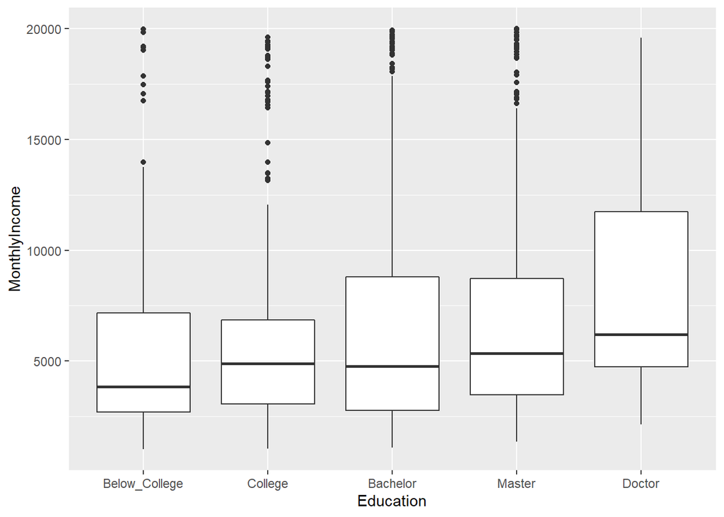

```r
# Load relevant library.
library(ggplot2)

# Plot.
ggplot(attrition1, aes(group = Education, x = Education, y = MonthlyIncome)) +
  geom_boxplot()
```

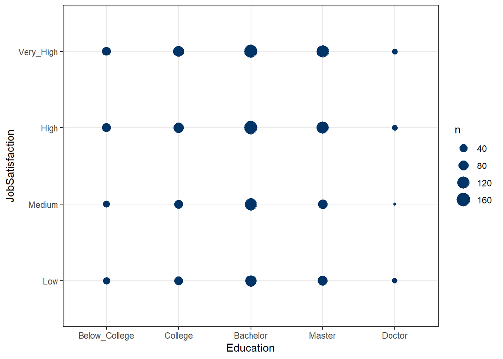

```r
# Plot.
ggplot(attrition1, aes(x = Education, y = JobSatisfaction), fill = JobSatisfaction) +
         geom_count(color = "#003366") +
         theme_bw()
```

**Visualization 3:** *Now explore the relationship between job level and education, which are both categorical factors, once again. From the graph, we could see that within the below college group, those who are at job level 1 take up the most of the group, which is more than a half. Job level 1 also take up most of the data included in group bachelor, but the “domination” is not as pronounced as the one observed in group below college. While for groups college, master, and doctor, job level 2 take up the biggest proportion of all the data included in these aforementioned groups. One interesting finding from the graph is that no matter what group it is, job level 5 takes up about the same proportion of the data within each group.*

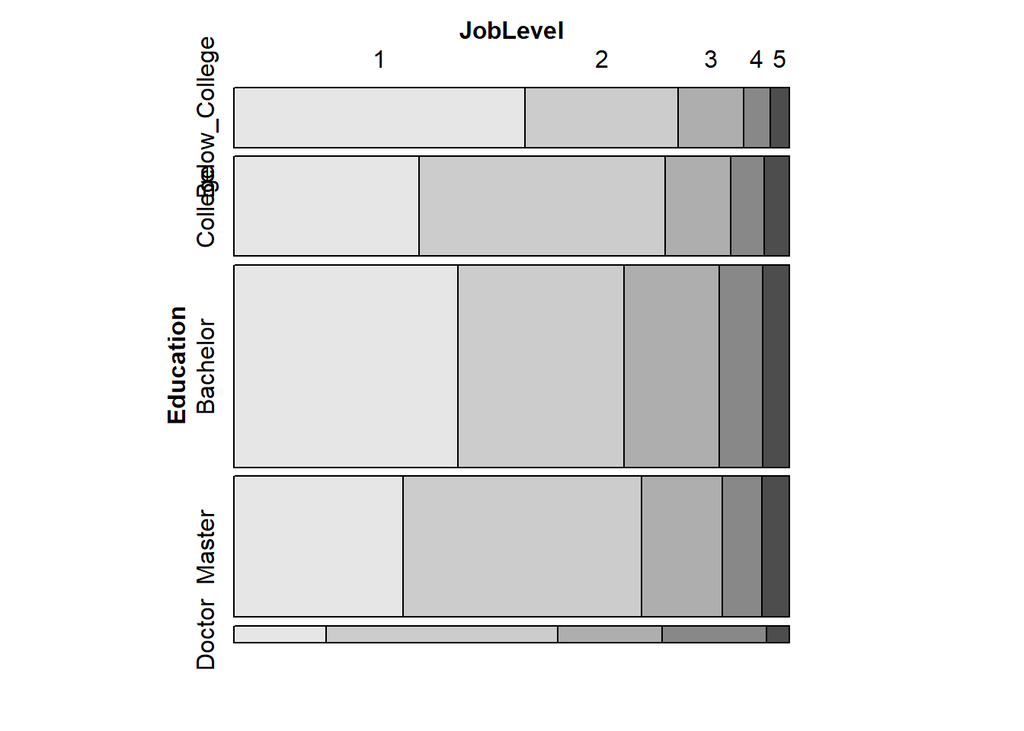

```r
# Load required package.
library(ggmosaic)
library(vcd)

# Plot.
mosaic(JobLevel ~ Education, data = attrition1)
```

**Visualization 4:** *Now I want to explore about the relationship between job level and job satisfaction, which are two categorical variables. We could see some interesting possible “pattern” from the graph: within the groups of job level 1 and 2, employees tend to have either high (/very high) or low job satisfaction. While this pattern starts to diminish and fade as the job level increases. Within the group of job level 3, we could still see that employees tend to have either high (/very high) or low job satisfaction. However, as we move onto group of job level 4, this pattern is not really obvious. Within the group of job level 5, more employees have medium to high job satisfaction.*

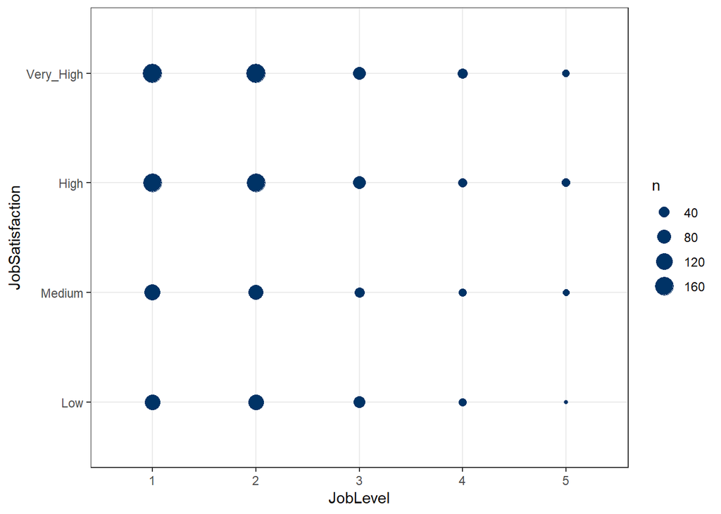

```r
# Plot.
ggplot(attrition1, aes(x = JobLevel, y = JobSatisfaction), fill = JobSatisfaction) +
         geom_count(color = "#003366") +
         theme_bw()
```

**Visualization 5:** *Finally, I am also intrigued to find out more about the relationship between job satisfaction and gender. Since both are categorical variables with small numbers of levels, I use the graph down below as my choice of plot. We could see that in general, male employees have a higher proportion of very high job satisfaction; while female employees have higher proportions of low, medium and high job satisfaction.*

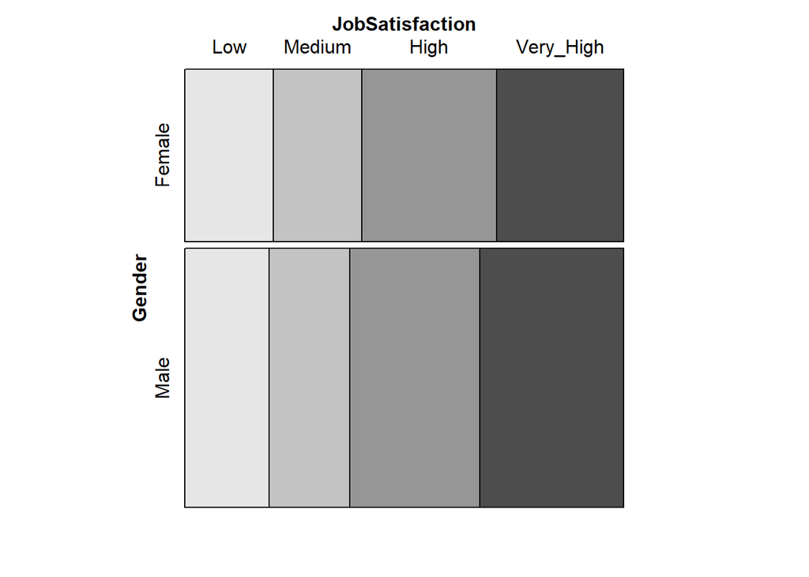

```r
# Plot.
mosaic(JobSatisfaction ~ Gender, data = attrition1)
```

## Task 5

Use the `simViz` function from inferviz to see how well you actually do in finding an actual relationship. First, pick two new variables for relationship exploration – make sure that you have not seen them before. When you run it the first time, keep the distractors argument at the default value. When asked if you want to see the real data select 1 (No). Now try it with more distractors (maybe 5 or 6).

How did you do? Where you able to spot the real relationship or were you fooled by your basic human need for pattern finding? Discuss what you think this means.

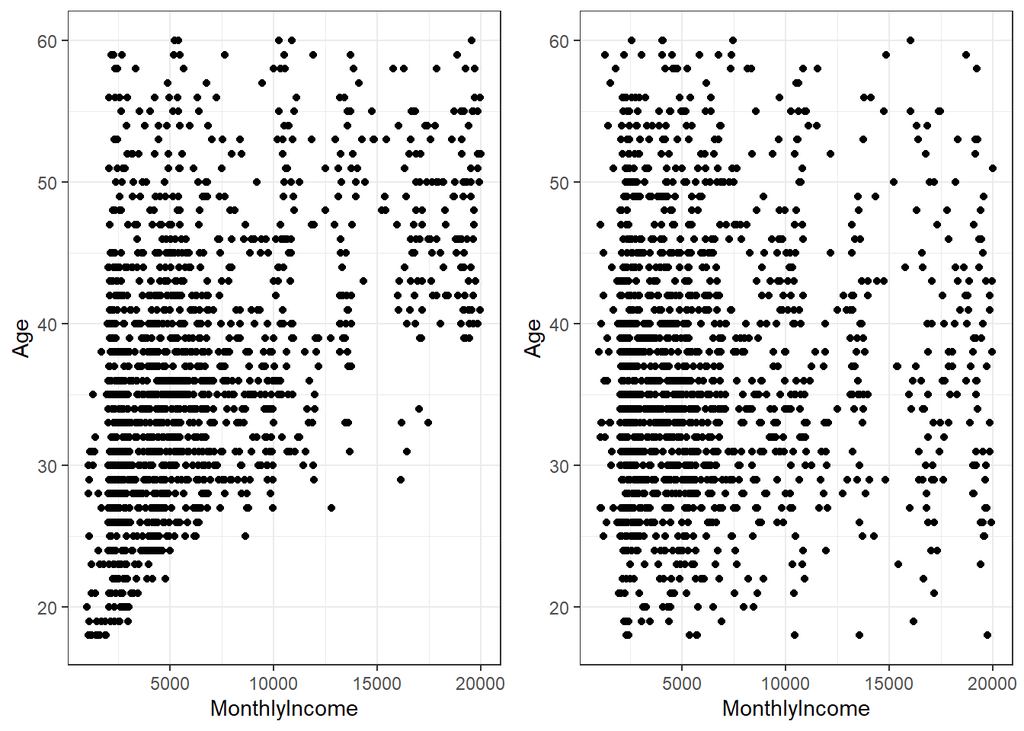

```r
# Load required package.
library(inferviz)

# Plot, with distractors set at 1.
simViz(attrition1, MonthlyIncome, Age, distractors = 1, answer = FALSE)
```

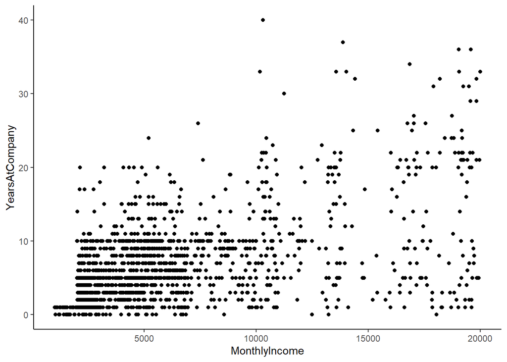

```r
# Plot, with basic plotting method.
ggplot(attrition1, aes(x = MonthlyIncome, y = YearsAtCompany))+
  geom_point()+
  theme_classic()
```

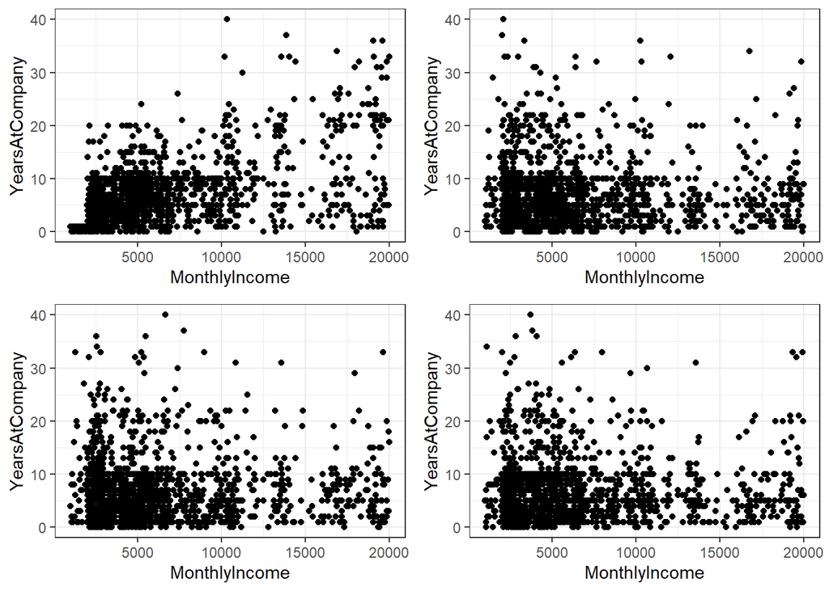

```r
# Plot, with distractors set at 3.
simViz(attrition1, MonthlyIncome, YearsAtCompany, distractors = 3, answer = FALSE)
```

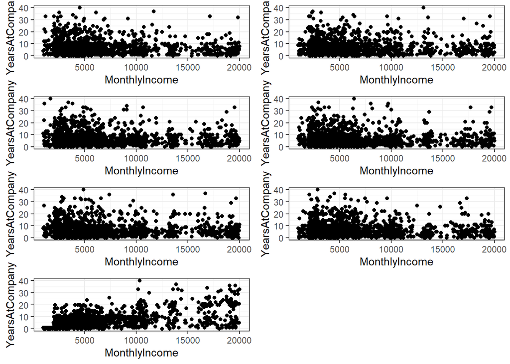

```r
# Plot, with distractors set at 3.
simViz(attrition1, MonthlyIncome, YearsAtCompany, distractors = 6, answer = FALSE)
```

# Silver Tier

For up to 4 points, use the leadershipRatingsAgreement.csv file in the data folder. You can use any of the following functions to read a csv file into R (from slow to fast):

```r
#read.csv("path/to/your/file.csv")
#readr::read_csv("path/to/your/file.csv")

# Read data.
leadership <- data.table::fread("leadershipRatingsAgreement.csv")

# Get a basic idea of the data.
str(leadership)
```

```
## Classes 'data.table' and 'data.frame':   4886 obs. of  8 variables:
##  $ leaderID    : int  2 3 6 7 9 10 11 12 14 15 ...
##  $ forceful    : num  0.6538 0.1539 0.0162 0.5637 0.702 ...
##  $ enabling    : num  0.668 0.58 0.234 0.119 0.315 ...
##  $ strategic   : num  0.6637 0.3369 0.1626 0.4747 0.0338 ...
##  $ operational : num  0.2598 0.0981 0.0927 0.1946 0.1502 ...
##  $ vitality    : num  -0.37 0.64 -0.718 0.213 0.129 ...
##  $ productivity: num  -0.04733 0.15063 -0.74538 0.63915 -0.00598 ...
##  $ effect      : num  0.516 0.608 0.854 1.046 1.95 ...
##  - attr(*, ".internal.selfref")=<externalptr>
```

From the following summary table, we could see that there are plenty NA’s, which might need to be dealt with in further endeavors.

```r
summary(leadership)
```

```
##     leaderID        forceful         enabling        strategic
##  Min.   :    2   Min.   :0.0000   Min.   :0.0000   Min.   :0.0000
##  1st Qu.: 3366   1st Qu.:0.1947   1st Qu.:0.1258   1st Qu.:0.1340
##  Median : 7021   Median :0.3346   Median :0.2375   Median :0.2345
##  Mean   : 6840   Mean   :0.4080   Mean   :0.3068   Mean   :0.2988
##  3rd Qu.:10256   3rd Qu.:0.5384   3rd Qu.:0.4056   3rd Qu.:0.3905
##  Max.   :13397   Max.   :2.5085   Max.   :2.2561   Max.   :2.6990
##                  NA's   :265      NA's   :265      NA's   :265
##   operational         vitality         productivity          effect
##  Min.   :0.00000   Min.   :-2.34009   Min.   :-2.25315   Min.   :0.0000
##  1st Qu.:0.06564   1st Qu.:-0.37076   1st Qu.:-0.53558   1st Qu.:0.5774
##  Median :0.11353   Median : 0.12525   Median : 0.08798   Median :0.8539
##  Mean   :0.13540   Mean   :-0.00305   Mean   :-0.00092   Mean   :0.9965
##  3rd Qu.:0.18044   3rd Qu.: 0.39491   3rd Qu.: 0.24458   3rd Qu.:1.2565
##  Max.   :1.12435   Max.   : 1.00665   Max.   : 0.96446   Max.   :4.9329
##  NA's   :265       NA's   :194        NA's   :194
```

Which variables have the strongest positive relationship and which have the strongest negative relationship?

*First, compute the correlationship table.*

```r
# First get rid of missing values in the dataset.
leadership1 <- na.omit(leadership)

# Second ger rid of the variables that are not necessarily useful.
leadership1 <- leadership1 %>%
  select(-leaderID)

# Now get the correlation table.
corrleadership <- round(cor(leadership1), 3)
head(corrleadership)
```

```
##              forceful enabling strategic operational vitality productivity
## forceful        1.000    0.599     0.493       0.584   -0.159       -0.081
## enabling        0.599    1.000     0.504       0.439   -0.183       -0.069
## strategic       0.493    0.504     1.000       0.457   -0.149       -0.111
## operational     0.584    0.439     0.457       1.000   -0.142       -0.103
## vitality       -0.159   -0.183    -0.149      -0.142    1.000        0.656
## productivity   -0.081   -0.069    -0.111      -0.103    0.656        1.000
##              effect
## forceful      0.348
## enabling      0.413
## strategic     0.351
## operational   0.300
## vitality     -0.214
## productivity -0.127
```

*Second, plot the correlation graph. We could see that vitality and productivity have the strongest positive relationship (rounded to 0.656), while the vitality and effect have the strongest negative relationship (rounded to -0.214).*

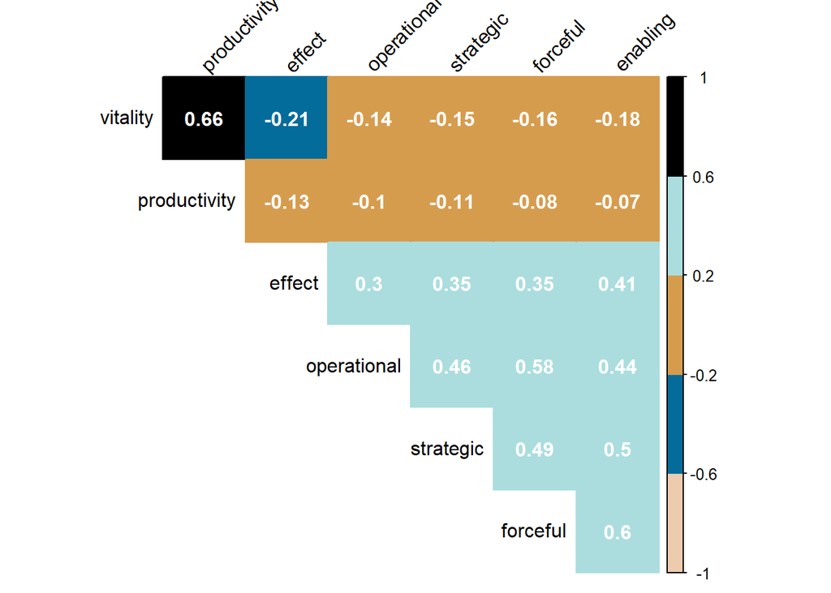

```r
# Load required package.
library(corrplot)

# Load color palette package.
library(wesanderson)

# Load in color.
col1 <- wes_palette("Darjeeling2")

# Plot.
corrplot(corrleadership, method = "color", col = col1, type = "upper", order = "hclust", addCoef.col = "white", tl.col = "black", tl.srt = 45, sig.level = 0.01, insig = "blank", diag = FALSE)
```

Once you have found those relationships, plot them both.

**(1-1) Vitality vs. Productivity - strongest positive relationship.** *With smoothing.*

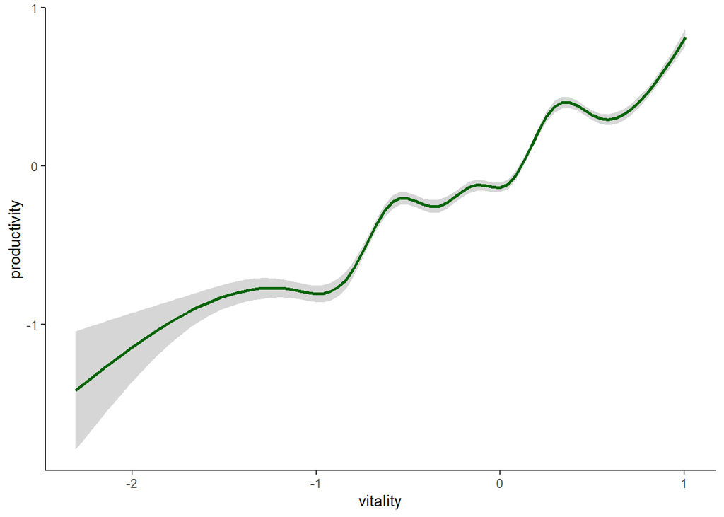

```r
# Plot.
ggplot(leadership1, aes(x = vitality, y = productivity)) +
  geom_smooth(color = "darkgreen") +
  theme_classic()
```

**(1-2) Vitality vs. Productivity - strongest positive relationship.** *With points plotted out.*

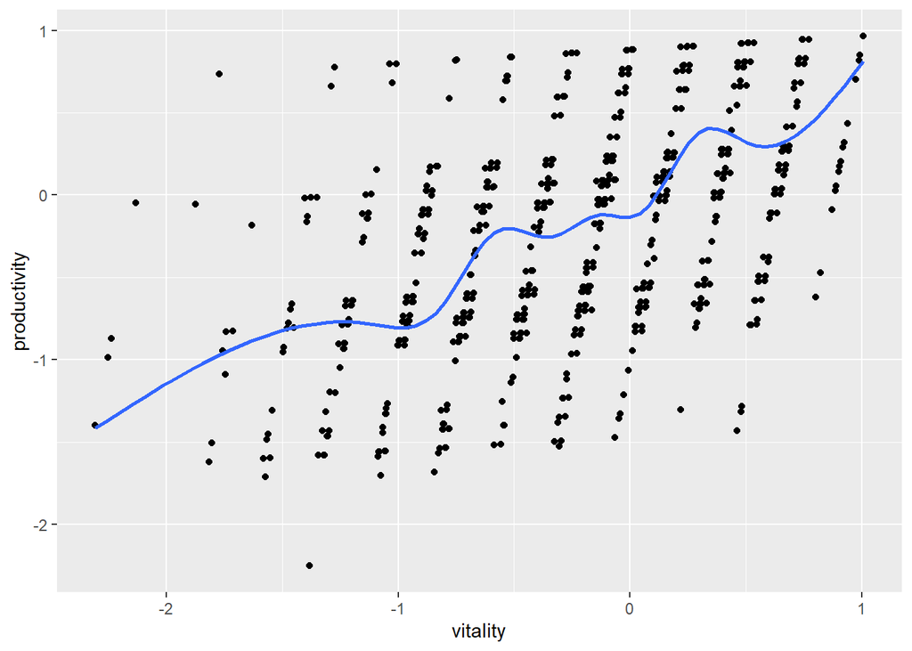

```r
# Plot.
ggplot(leadership1, aes(x = vitality, y = productivity)) +
  geom_point() +
  geom_smooth(se=FALSE)
```

**(2) Vitality vs. Effect - strongest negative relationship.** *Wtih smoothing.*

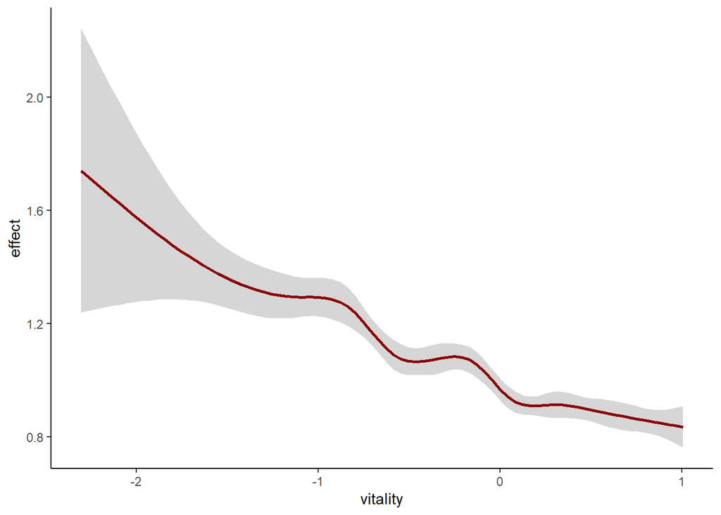

```r
# Plot.
ggplot(leadership1, aes(x = vitality, y = effect)) +
  geom_smooth(color = "darkred") +
  theme_classic()
```

**(2-2) Vitality vs. Effect - strongest negative relationship.** *With points plotted out.*

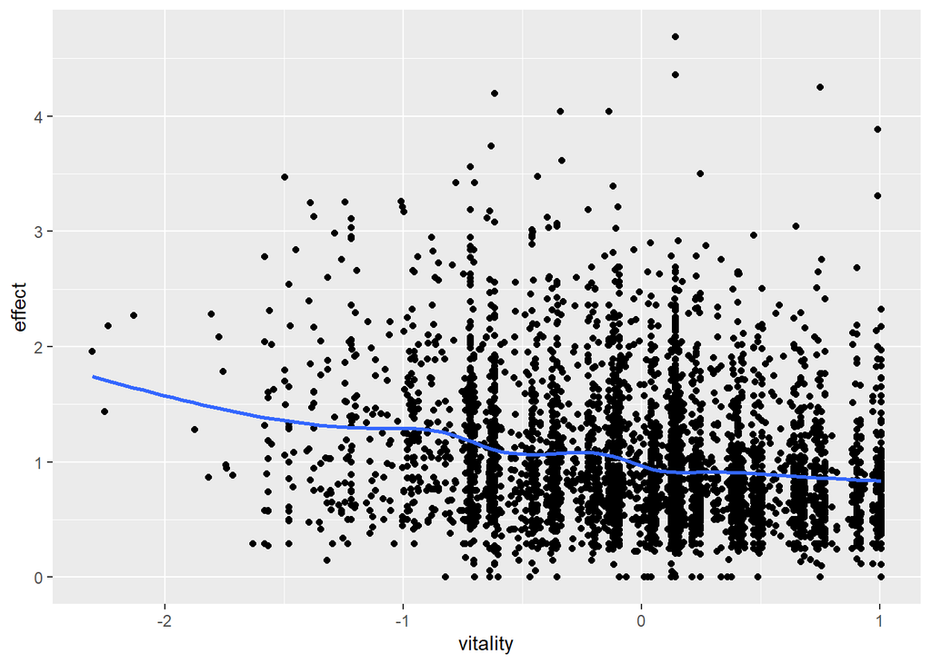

```r
# Plot.
ggplot(leadership1, aes(x = vitality, y = effect)) +
  geom_point() +
  geom_smooth(se=FALSE)
```

Which 4 variables have the strongest relationship with the effect variable? Explain how you found this relationship. Produce plots for each of those relationships and include both linear trend lines and smoothed trend lines.

*For this problem, we could refer back to correlation matrix and correlation plot. Based on the absolute value of the respective correlation coefficients , we could see that the 4 variables which have the strongest relationships with the effect variables include: forceful, enabling, strategic, and operational. Now the plots are as follows. Linear trend lines are in red; smoothed trend lines are in blue.*

**Plot 1: effect vs. forceful.** *Positive relationship.*

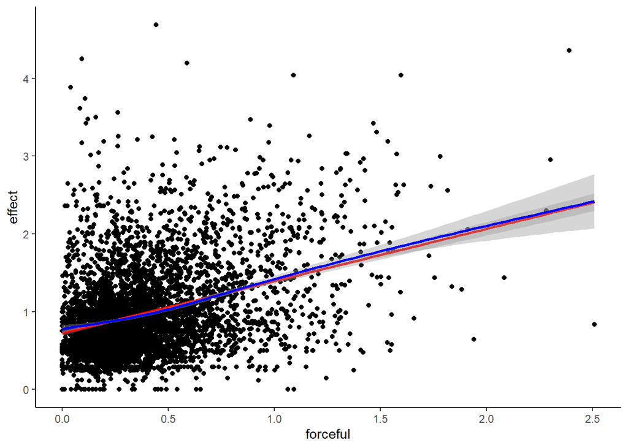

```r
#Plot.
ggplot(leadership1, aes(x = forceful, y = effect)) +
  geom_point() +
  geom_smooth(method = lm, color = "red") +
  geom_smooth(color = "blue") +
  theme_classic()
```

**Plot 2: effect vs. enabling.** *Positive relationship.*

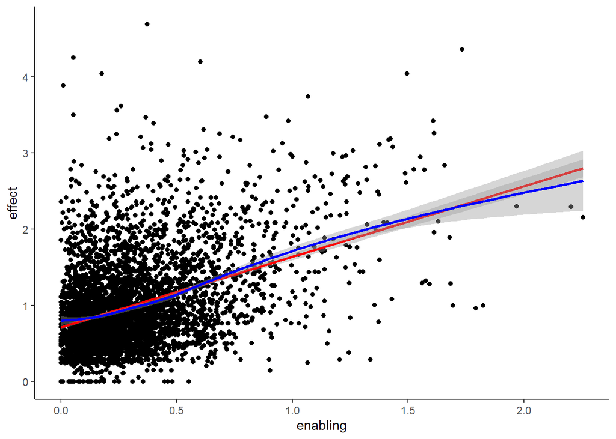

```r
#Plot.
ggplot(leadership1, aes(x = enabling, y = effect)) +
  geom_point() +
  geom_smooth(method = lm, color = "red") +
  geom_smooth(color = "blue") +
  theme_classic()
```

**Plot 3: effect vs. strategic.** *Positive relationship.*

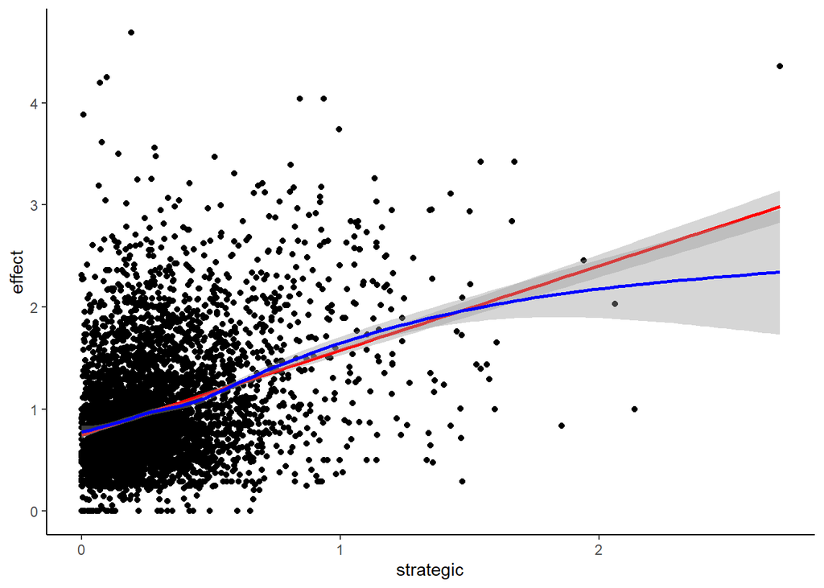

```r
#Plot.
ggplot(leadership1, aes(x = strategic, y = effect)) +
  geom_point() +
  geom_smooth(method = lm, color = "red") +
  geom_smooth(color = "blue") +
  theme_classic()
```

**Plot 4: effect vs. operational.** *Positive relationship.*

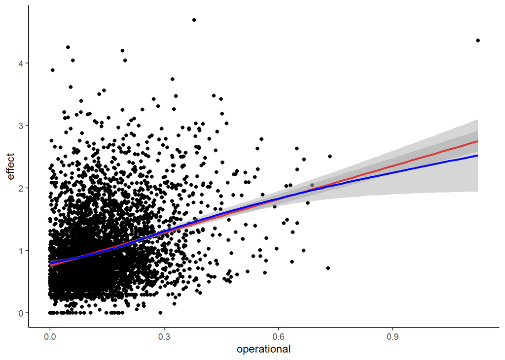

```r
#Plot.
ggplot(leadership1, aes(x = operational, y = effect)) +
  geom_point() +
  geom_smooth(method = lm, color = "red") +
  geom_smooth(color = "blue") +
  theme_classic()
```

**Collected plots.** *Arrange these four graphs altogether, and see if it is possible to compare through the collected visualization. Some observations are: the lines for forceful vs. effect is flatter than the lines for enabling vs. effect; the linear trend line for strategic vs. effect is steeper than the linear trend line for forceful vs. effect; and etc. Since the four plots are plotted on different scales - certian alteration might be needed to have more effective and direct comparisons.*

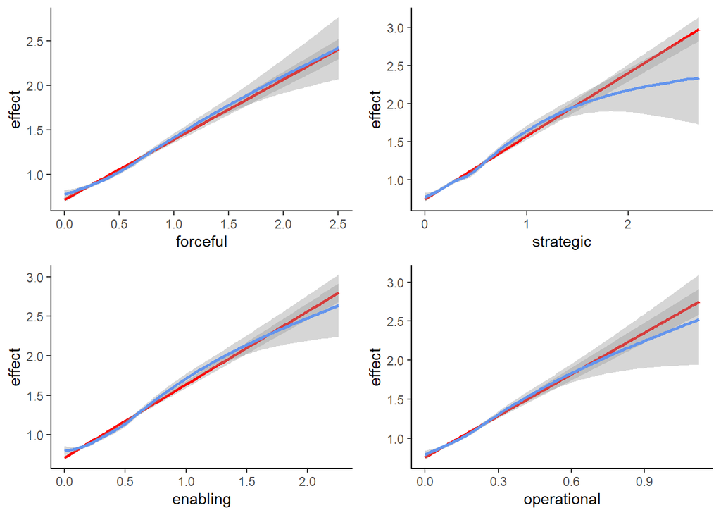

```r
a <- leadership1 %>%
  ggplot(mapping = aes(x = forceful, y = effect))+
  geom_smooth(method = lm, color = "red")+
  geom_smooth(color = "cornflowerblue")+
  theme_classic()

b <- leadership1 %>%
  ggplot(mapping = aes(x = enabling, y = effect))+
  geom_smooth(method = lm, color = "red")+
  geom_smooth(color = "cornflowerblue")+
  theme_classic()

c <- leadership1 %>%
  ggplot(mapping = aes(x = strategic, y = effect))+
  geom_smooth(method = lm, color = "red")+
  geom_smooth(color = "cornflowerblue")+
  theme_classic()

d <- leadership1 %>%
  ggplot(mapping = aes(x = operational, y = effect))+
  geom_smooth(method = lm, color = "red")+
  geom_smooth(color = "cornflowerblue")+
  theme_classic()

multiplot(a, b, c, d, cols = 2)
```

# Gold Tier

For up to 6 points, use the leadership data found in the data folder. This is a .dta file (from Stata) and can be read in using the appropriate function from the haven package.

```r
lead <- haven::read_dta("leadership")
```

Using verbs from the dplyr package (specifically, `group_by` and `summarize`), find the *effect* mean for each leaderID. Which leader(s) had the highest effect mean and which leader(s) had the lowest effect mean.

*From the results, we could see leaderID 1644, 2507, and 8467 have the highest effect mean. LeaderID 1589 has the lowest effect mean.*

```r
# Compute and summarize the effect means for each leaderID.
lead %>%
  group_by(leaderID) %>%
  summarise(mean = round(mean(effect), 2))
```

```
## # A tibble: 4,886 x 2
##    leaderID  mean
##       <dbl> <dbl>
##  1        2  8.33
##  2        3  8.7
##  3        6  7.62
##  4        7  8.72
##  5        9  7.18
##  6       10  8.12
##  7       11  8.96
##  8       12  8.5
##  9       14  8.25
## 10       15  8.92
## # ... with 4,876 more rows
```

```r
# Find the leader(s) with the highest effect mean.
lead %>%
  group_by(leaderID) %>%
  summarise(mean = round(mean(effect), 2)) %>%
  arrange(desc(mean))
```

```
## # A tibble: 4,886 x 2
##    leaderID  mean
##       <dbl> <dbl>
##  1     1644 10
##  2     2507 10
##  3     8467 10
##  4     1638  9.97
##  5    11880  9.95
##  6     6606  9.88
##  7    11029  9.88
##  8     6312  9.83
##  9     8926  9.83
## 10    10891  9.83
## # ... with 4,876 more rows
```

```r
# Find the leader(s) with the lowest effect mean.
lead %>%
  group_by(leaderID) %>%
  summarise(mean = round(mean(effect), 2)) %>%
  arrange(mean)
```

```
## # A tibble: 4,886 x 2
##    leaderID  mean
##       <dbl> <dbl>
##  1     1589  2.17
##  2     5100  2.75
##  3    12191  3.67
##  4     9545  3.75
##  5    12261  4.3
##  6     2176  4.31
##  7     3270  4.5
##  8     4084  4.5
##  9     6093  4.5
## 10    12890  4.5
## # ... with 4,876 more rows
```

Take your highest and lowest leaders and keep the leaderID. With the leaderID in hand, find those leaders in the leadershipRatingsAgreement data.

*Highest Leader IDs: 1644, 2507, and 8467. Lowest Leader IDs: 1589.*

```r
# Extract the 4 leaders from the leadershipRatingsAgreement data.
MaxMinMean <- leadership %>%
  filter(leaderID == 8467 | leaderID == 2507 | leaderID == 1644 | leaderID == 1589)
```

Excluding effect, construct a plot with forceful, enabling, strategic, operational, vitality, and productivity on the x-axis (the y-axis will contain the value for each variable). Next color the points by leaderID.

*Plot.*

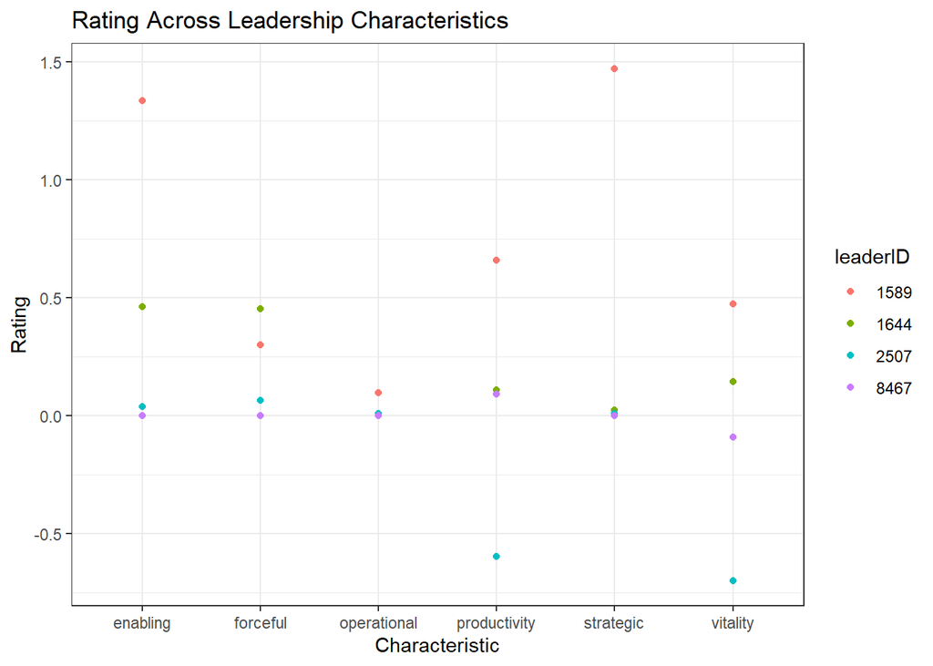

```r
# Plot.
MaxMinMean %>%
  gather(key = "Characteristic", value = "Rating", -leaderID, -effect) %>%
  mutate(leaderID = as.factor(leaderID)) %>%
  ggplot(mapping = aes (x = Characteristic, y = Rating, color = leaderID)) +
  geom_point() +
  ggtitle("Rating Across Leadership Characteristics") +
  theme_bw()
```